# Part_I_exploration

## Table of content

1. Dataset
2. Data Source
3. Introduction
4. Research Question
5. Libraries
6. Gather Data
7. Assessing Data
8. Features of Interest
9. Univariate Exploration
10. Bivariate Exploration
11. Multivariate Exploration
12. Conclusion

### Dataset: (Prosper Loan Data)

### project 3: Exploratory Data Analysis

#### By: Thomas Oluwasegun Olubunmi

### Data Source

https://s3.amazonaws.com/udacity-hosted-downloads/ud651/prosperLoanData.csv

### Introduction

`Loan Data from Prosper:` This data set contains 113,937 loans with 81 variables on each loan, including loan amount, borrower rate (or interest rate), current loan status, borrower income, and many others. The objectives of this project are to summarize the characteristics of features that have effect on the loan status and to get some ideas about the relationships among multiple features using summary statistics and data visualizations.

### Research Question:

1. What is the highest proportion of income range of the borrower?
2. Which credit grade is the most common among the people taking loan?
3. Is there any relationship between interest rate and credit grade?
4. How does monthly loan payment affect the score of loan takers?
5. How does credit rate, monthly loan payment affect borrower APR?

### Libraries

```python
# import all packages
import numpy as np
import pandas as pd
import matplotlib.pyplot as plt
import seaborn as sns
```

#### Gather Data

Manually Download the data from the Prosper Loan Data from the given url

```python
url = "https://s3.amazonaws.com/udacity-hosted-downloads/ud651/prosperLoanData.csv"
data = pd.read_csv(url)
```

```python
#data.to_csv("prosperLoanData.csv", index = False)
```

#### Assessing the data

```python
# check the first five rows
data.head()
```

|  | ListingKey | ListingNumber | ListingCreationDate | CreditGrade | Term | LoanStatus | ClosedDate | BorrowerAPR | BorrowerRate | LenderYield | ... | LP_ServiceFees | LP_CollectionFees | LP_GrossPrincipalLoss | LP_NetPrincipalLoss | LP_NonPrincipalRecoverypayments | PercentFunded | Recommendations | InvestmentFromFriendsCount | InvestmentFromFriendsAmount | Investors |
| --- | --- | --- | --- | --- | --- | --- | --- | --- | --- | --- | --- | --- | --- | --- | --- | --- | --- | --- | --- | --- | --- |
| 0 | 1021339766868145413AB3B | 193129 | 2007-08-26 19:09:29.263000000 | C | 36 | Completed | 2009-08-14 00:00:00 | 0.16516 | 0.1580 | 0.1380 | ... | -133.18 | 0.0 | 0.0 | 0.0 | 0.0 | 1.0 | 0 | 0 | 0.0 | 258 |
| 1 | 10273602499503308B223C1 | 1209647 | 2014-02-27 08:28:07.900000000 | NaN | 36 | Current | NaN | 0.12016 | 0.0920 | 0.0820 | ... | 0.00 | 0.0 | 0.0 | 0.0 | 0.0 | 1.0 | 0 | 0 | 0.0 | 1 |
| 2 | 0EE9337825851032864889A | 81716 | 2007-01-05 15:00:47.090000000 | HR | 36 | Completed | 2009-12-17 00:00:00 | 0.28269 | 0.2750 | 0.2400 | ... | -24.20 | 0.0 | 0.0 | 0.0 | 0.0 | 1.0 | 0 | 0 | 0.0 | 41 |
| 3 | 0EF5356002482715299901A | 658116 | 2012-10-22 11:02:35.010000000 | NaN | 36 | Current | NaN | 0.12528 | 0.0974 | 0.0874 | ... | -108.01 | 0.0 | 0.0 | 0.0 | 0.0 | 1.0 | 0 | 0 | 0.0 | 158 |
| 4 | 0F023589499656230C5E3E2 | 909464 | 2013-09-14 18:38:39.097000000 | NaN | 36 | Current | NaN | 0.24614 | 0.2085 | 0.1985 | ... | -60.27 | 0.0 | 0.0 | 0.0 | 0.0 | 1.0 | 0 | 0 | 0.0 | 20 |

5 rows × 81 columns

```python
# View the last five rows
data.tail()
```

|  | ListingKey | ListingNumber | ListingCreationDate | CreditGrade | Term | LoanStatus | ClosedDate | BorrowerAPR | BorrowerRate | LenderYield | ... | LP_ServiceFees | LP_CollectionFees | LP_GrossPrincipalLoss | LP_NetPrincipalLoss | LP_NonPrincipalRecoverypayments | PercentFunded | Recommendations | InvestmentFromFriendsCount | InvestmentFromFriendsAmount | Investors |
| --- | --- | --- | --- | --- | --- | --- | --- | --- | --- | --- | --- | --- | --- | --- | --- | --- | --- | --- | --- | --- | --- |
| 113932 | E6D9357655724827169606C | 753087 | 2013-04-14 05:55:02.663000000 | NaN | 36 | Current | NaN | 0.22354 | 0.1864 | 0.1764 | ... | -75.58 | 0.0 | 0.0 | 0.0 | 0.0 | 1.0 | 0 | 0 | 0.0 | 1 |
| 113933 | E6DB353036033497292EE43 | 537216 | 2011-11-03 20:42:55.333000000 | NaN | 36 | FinalPaymentInProgress | NaN | 0.13220 | 0.1110 | 0.1010 | ... | -30.05 | 0.0 | 0.0 | 0.0 | 0.0 | 1.0 | 0 | 0 | 0.0 | 22 |
| 113934 | E6E13596170052029692BB1 | 1069178 | 2013-12-13 05:49:12.703000000 | NaN | 60 | Current | NaN | 0.23984 | 0.2150 | 0.2050 | ... | -16.91 | 0.0 | 0.0 | 0.0 | 0.0 | 1.0 | 0 | 0 | 0.0 | 119 |
| 113935 | E6EB3531504622671970D9E | 539056 | 2011-11-14 13:18:26.597000000 | NaN | 60 | Completed | 2013-08-13 00:00:00 | 0.28408 | 0.2605 | 0.2505 | ... | -235.05 | 0.0 | 0.0 | 0.0 | 0.0 | 1.0 | 0 | 0 | 0.0 | 274 |
| 113936 | E6ED3600409833199F711B7 | 1140093 | 2014-01-15 09:27:37.657000000 | NaN | 36 | Current | NaN | 0.13189 | 0.1039 | 0.0939 | ... | -1.70 | 0.0 | 0.0 | 0.0 | 0.0 | 1.0 | 0 | 0 | 0.0 | 1 |

5 rows × 81 columns

```python
# Get the basic info about the prosper loan dataset
print(data.info())
```

```
<class 'pandas.core.frame.DataFrame'>
RangeIndex: 113937 entries, 0 to 113936
Data columns (total 81 columns):
ListingKey                             113937 non-null object
ListingNumber                          113937 non-null int64
ListingCreationDate                    113937 non-null object
CreditGrade                            28953 non-null object
Term                                   113937 non-null int64
LoanStatus                             113937 non-null object
ClosedDate                             55089 non-null object
BorrowerAPR                            113912 non-null float64
BorrowerRate                           113937 non-null float64
LenderYield                            113937 non-null float64
EstimatedEffectiveYield                84853 non-null float64
EstimatedLoss                          84853 non-null float64
EstimatedReturn                        84853 non-null float64
ProsperRating (numeric)                84853 non-null float64
ProsperRating (Alpha)                  84853 non-null object
ProsperScore                           84853 non-null float64
ListingCategory (numeric)              113937 non-null int64
BorrowerState                          108422 non-null object
Occupation                             110349 non-null object
EmploymentStatus                       111682 non-null object
EmploymentStatusDuration               106312 non-null float64
IsBorrowerHomeowner                    113937 non-null bool
CurrentlyInGroup                       113937 non-null bool
GroupKey                               13341 non-null object
DateCreditPulled                       113937 non-null object
CreditScoreRangeLower                  113346 non-null float64
CreditScoreRangeUpper                  113346 non-null float64
FirstRecordedCreditLine                113240 non-null object
CurrentCreditLines                     106333 non-null float64
OpenCreditLines                        106333 non-null float64
TotalCreditLinespast7years             113240 non-null float64
OpenRevolvingAccounts                  113937 non-null int64
OpenRevolvingMonthlyPayment            113937 non-null float64
InquiriesLast6Months                   113240 non-null float64
TotalInquiries                         112778 non-null float64
CurrentDelinquencies                   113240 non-null float64
AmountDelinquent                       106315 non-null float64
```

[output cut: 32 more lines]

```
LP_CustomerPrincipalPayments           113937 non-null float64
LP_InterestandFees                     113937 non-null float64
LP_ServiceFees                         113937 non-null float64
LP_CollectionFees                      113937 non-null float64
LP_GrossPrincipalLoss                  113937 non-null float64
LP_NetPrincipalLoss                    113937 non-null float64
LP_NonPrincipalRecoverypayments        113937 non-null float64
PercentFunded                          113937 non-null float64
Recommendations                        113937 non-null int64
InvestmentFromFriendsCount             113937 non-null int64
InvestmentFromFriendsAmount            113937 non-null float64
Investors                              113937 non-null int64
dtypes: bool(3), float64(50), int64(11), object(17)
memory usage: 68.1+ MB
None
```

```python
# check the shape of the data
data.shape
```

```
(113937, 81)
```

```python
# count the missing rows
print(data.isna().sum())
```

```
ListingKey                                  0
ListingNumber                               0
ListingCreationDate                         0
CreditGrade                             84984
Term                                        0
LoanStatus                                  0
ClosedDate                              58848
BorrowerAPR                                25
BorrowerRate                                0
LenderYield                                 0
EstimatedEffectiveYield                 29084
EstimatedLoss                           29084
EstimatedReturn                         29084
ProsperRating (numeric)                 29084
ProsperRating (Alpha)                   29084
ProsperScore                            29084
ListingCategory (numeric)                   0
BorrowerState                            5515
Occupation                               3588
EmploymentStatus                         2255
EmploymentStatusDuration                 7625
IsBorrowerHomeowner                         0
CurrentlyInGroup                            0
GroupKey                               100596
DateCreditPulled                            0
CreditScoreRangeLower                     591
CreditScoreRangeUpper                     591
FirstRecordedCreditLine                   697
CurrentCreditLines                       7604
OpenCreditLines                          7604
                                        ...
TotalProsperLoans                       91852
TotalProsperPaymentsBilled              91852
OnTimeProsperPayments                   91852
ProsperPaymentsLessThanOneMonthLate     91852
ProsperPaymentsOneMonthPlusLate         91852
ProsperPrincipalBorrowed                91852
ProsperPrincipalOutstanding             91852
ScorexChangeAtTimeOfListing             95009
LoanCurrentDaysDelinquent                   0
LoanFirstDefaultedCycleNumber           96985
LoanMonthsSinceOrigination                  0
LoanNumber                                  0
LoanOriginalAmount                          0
LoanOriginationDate                         0
LoanOriginationQuarter                      0
MemberKey                                   0
MonthlyLoanPayment                          0
LP_CustomerPayments                         0
LP_CustomerPrincipalPayments                0
LP_InterestandFees                          0
LP_ServiceFees                              0
LP_CollectionFees                           0
LP_GrossPrincipalLoss                       0
LP_NetPrincipalLoss                         0
LP_NonPrincipalRecoverypayments             0
PercentFunded                               0
Recommendations                             0
InvestmentFromFriendsCount                  0
InvestmentFromFriendsAmount                 0
Investors                                   0
Length: 81, dtype: int64
```

```python
# check if there is duplicate
print(data.duplicated().sum())
```

```
0
```

```python
# check for unique values
print(data.nunique())
```

```
ListingKey                             113066
ListingNumber                          113066
ListingCreationDate                    113064
CreditGrade                                 8
Term                                        3
LoanStatus                                 12
ClosedDate                               2802
BorrowerAPR                              6677
BorrowerRate                             2294
LenderYield                              2283
EstimatedEffectiveYield                  1582
EstimatedLoss                             120
EstimatedReturn                          1476
ProsperRating (numeric)                     7
ProsperRating (Alpha)                       7
ProsperScore                               11
ListingCategory (numeric)                  21
BorrowerState                              51
Occupation                                 67
EmploymentStatus                            8
EmploymentStatusDuration                  605
IsBorrowerHomeowner                         2
CurrentlyInGroup                            2
GroupKey                                  706
DateCreditPulled                       112992
CreditScoreRangeLower                      26
CreditScoreRangeUpper                      26
FirstRecordedCreditLine                 11585
CurrentCreditLines                         54
OpenCreditLines                            52
                                        ...
TotalProsperLoans                           9
TotalProsperPaymentsBilled                130
OnTimeProsperPayments                     127
ProsperPaymentsLessThanOneMonthLate        41
ProsperPaymentsOneMonthPlusLate            17
ProsperPrincipalBorrowed                 1442
ProsperPrincipalOutstanding             13875
ScorexChangeAtTimeOfListing               372
LoanCurrentDaysDelinquent                2411
LoanFirstDefaultedCycleNumber              43
LoanMonthsSinceOrigination                 94
LoanNumber                             113066
LoanOriginalAmount                       2468
LoanOriginationDate                      1873
LoanOriginationQuarter                     33
MemberKey                               90831
MonthlyLoanPayment                      23567
LP_CustomerPayments                     78523
LP_CustomerPrincipalPayments            49828
LP_InterestandFees                      78751
LP_ServiceFees                          19813
LP_CollectionFees                        6175
LP_GrossPrincipalLoss                   15848
LP_NetPrincipalLoss                     15709
LP_NonPrincipalRecoverypayments          2631
PercentFunded                             719
Recommendations                            17
InvestmentFromFriendsCount                 14
InvestmentFromFriendsAmount               726
Investors                                 751
Length: 81, dtype: int64
```

#### Features of interest

| Variable | Description |
| --- | --- |
| ProsperScore | Risk Factor score from 1 to 10. 10 being least risky |
| EmploymentStatus | Current type of employment |
| EmploymentStatusDuration | How long the employee has been employed |
| DebtToIncomeRatio | The debt to income ratio of the borrower at the time the credit profile was pulled |
| StatedMonthlyIncome | Monthly income of the borrower |
| Occupation | Occupation of borrower at the time of listing |
| IsBorrowerHomeowner | Does the borrower owns house at the time of listing (True & False) |
| IncomeRange | The income range of the borrower at the time the listing was created |
| IncomeVerifiable | If the income of the borrower is verifiable at the time of listing (True & False) |
| BorrowerAPR | The Borrower’s Annual Percentage Rate (APR) for the loan |
| BorrowerRate | The Borrower’s interest rate for this loan |
| LoanStatus | Current status of the loan like chargedoff, completed, defauted etc… |
| CreditGrade | The Credit rating that was assigned at the time the listing went live |
| MonthlyLoanPayment | Monthly loan payment amount |

### Visualization and Analysis

### Univariate Exploration

```python
# create a wrange function
def wrangle(filepath):
    # Read csv file
    df = pd.read_csv(filepath)

    # remove outliers
    low, high = df["StatedMonthlyIncome"].quantile([0.1, 0.9])
    mask = df["StatedMonthlyIncome"].between(low, high)
    df = df[mask]

    low, high = df["DebtToIncomeRatio"].quantile([0.1, 0.9])
    mask_d = df["DebtToIncomeRatio"].between(low, high)
    df = df[mask_d]
     # drop NaNs Values
    df = df[ (df["Occupation"] != "Other") & (df["Occupation"] != "Professional")\
             & (~df["Occupation"].isna())]
    df = df[(~df.BorrowerAPR.isna())]
    df = df[(~df.IncomeRange.isna())]

    return df
```

```python
# use the wrangle function to load the data into dataframe
df = wrangle("prosperLoanData.csv")
```

```python
# Convert ProsperRating and credit grade into ordered categorical types
rate_order = ['HR','E','D','C','B','A','AA']
df['ProsperRating (Alpha)'] = df['ProsperRating (Alpha)'].astype("category")
df['ProsperRating (Alpha)'] = df['ProsperRating (Alpha)'].cat.set_categories(
                                    new_categories = rate_order, ordered = True)

grade_order = ['HR','E','D','C','B','A','AA']
df['CreditGrade'] = df['CreditGrade'].astype("category")
df['CreditGrade'] = df['CreditGrade'].cat.set_categories(
                                    new_categories = rate_order, ordered = True)
```

```python
# create a function to label axes and set tit
def label(xaxis, yaxis, title):
    """This function set the label axes and title of plots"""
    plt.xlabel(xaxis)
    plt.ylabel(yaxis)
    plt.title(title)
```

```python
# Summarry statistics
df[["BorrowerAPR", "BorrowerRate"]].describe()
```

|  | BorrowerAPR | BorrowerRate |
| --- | --- | --- |
| count | 42641.000000 | 42641.000000 |
| mean | 0.214555 | 0.188281 |
| std | 0.077950 | 0.072768 |
| min | 0.015480 | 0.000500 |
| 25% | 0.153240 | 0.130000 |
| 50% | 0.204360 | 0.177400 |
| 75% | 0.274340 | 0.245200 |
| max | 0.413550 | 0.360000 |

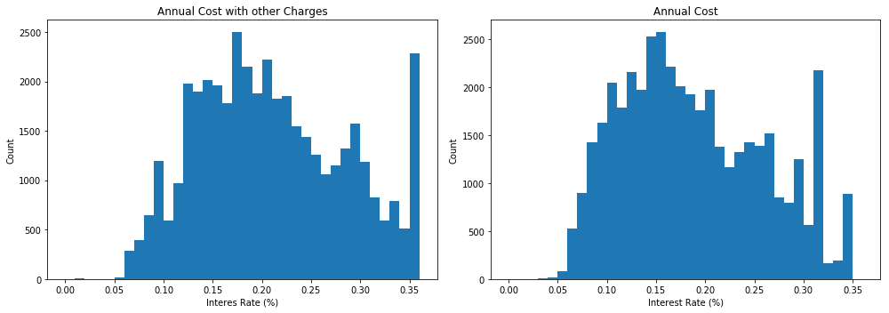

```python
# set the figure set
plt.rcParams['figure.figsize'] = 14, 5

fig, ax = plt.subplots(ncols = 2)

bins = np.arange(0, df["BorrowerAPR"].max()+0.01, 0.01)
bin_s = bins = np.arange(0, df["BorrowerRate"].max()+0.01, 0.01)
# plot
ax[0].hist(data = df, x="BorrowerAPR", bins = bins)
ax[1].hist(data = df, x="BorrowerRate", bins = bin_s)

# label the axes
ax[0].set_ylabel("Count")
ax[0].set_xlabel('Interes Rate (%)')
ax[1].set_xlabel("Interest Rate (%)")
ax[1].set_ylabel("Count")

# title
ax[0].set_title("Annual Cost with other Charges")
ax[1].set_title("Annual Cost")

plt.tight_layout()
# show the plot
plt.show()
```

> - Both BorrowerAPR and BorrowerRate interes rate are normally distributed. However, both have spikes.

#### Monthly Loan payment

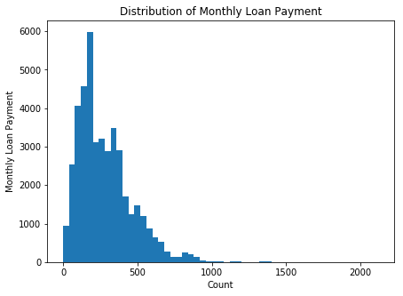

```python
# set the figure set
plt.rcParams['figure.figsize'] = 7, 5
bins = np.arange(0, df["MonthlyLoanPayment"].max()+40, 40)
# plot
plt.hist(data = df, x="MonthlyLoanPayment", bins = bins)
# label the axes and set title
label("Count", "Monthly Loan Payment", "Distribution of Monthly Loan Payment")
# show plot
plt.show()
```

#### Debt to Income Ratio

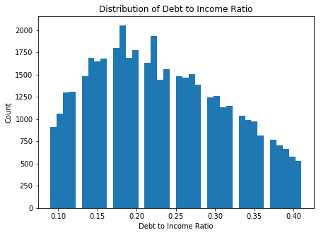

```python
# set the figure set
plt.rcParams['figure.figsize'] = 7, 5
# plot
plt.hist(data = df, x = "DebtToIncomeRatio", bins = 40)

# label the axes and set the title
label("Debt to Income Ratio", "Count", "Distribution of Debt to Income Ratio")
# show the plot
plt.show()
```

> - Debt to income ratio is skewed to the right.

### Question

#### What is the highest proportion of income range of the borrower ?

```python
income = df[df["IncomeRange"] != "Not displayed"]
income = income["IncomeRange"].value_counts(normalize = True).sort_values()
income
```

```
$1-24,999         0.000049
Not employed      0.000098
$100,000+         0.081485
$75,000-99,999    0.212677
$25,000-49,999    0.327113
$50,000-74,999    0.378578
Name: IncomeRange, dtype: float64
```

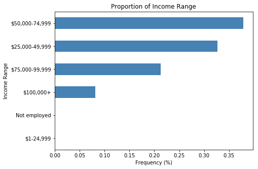

```python
plt.rcParams["figure.figsize"] = 7, 5
ax = income.plot(kind = "barh", color = "steelblue")

# Label the axes set the title
label("Frequency (%)", "Income Range", "Proportion of Income Range")
plt.show()
```

#### Stated Monthly Income

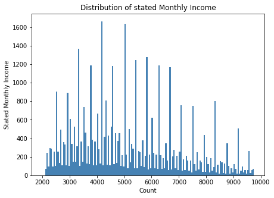

```python
# Set the
plt.rcParams['figure.figsize'] = 7, 5
bins = np.arange(2000, df["StatedMonthlyIncome"].max()+50, 50)
plt.hist(data = df, x = "StatedMonthlyIncome",bins=bins, color='steelblue')
# set title and label axes
label("Count", "Stated Monthly Income", "Distribution of stated Monthly Income")
plt.show()
```

#### Occupation

```python
# Remove the Nans
occupation = df["Occupation"].value_counts().sort_values()
```

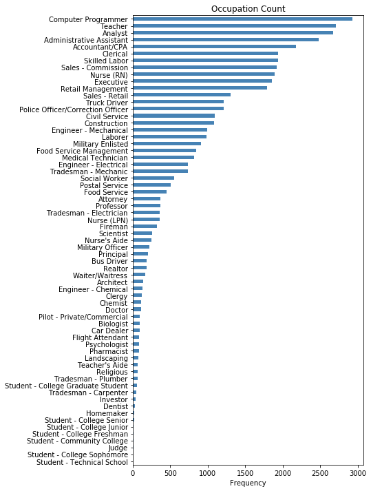

```python
plt.rcParams['figure.figsize'] = 6, 12

# plot
occupation.plot(kind = 'barh', color = 'steelblue')

# Label the axes and set title
label("Frequency", "", "Occupation Count");
```

- `Computer programmer`, `Teacher` and `Analyst` are the 3 most common occupation

#### Question 2:

> Which credit grade is the most common among the people taking loan?

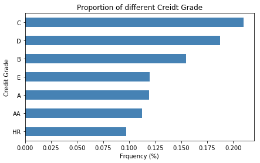

```python
plt.rcParams['figure.figsize'] = 7, 4
credit = df["CreditGrade"].value_counts(normalize = True).sort_values()

# plot
credit.plot(kind = "barh", color = "steelblue")

# set title and label axes
label("Frquency (%)", "Credit Grade", "Proportion of different Creidt Grade")
plt.show()
```

#### Observation

> - Grade C is the most common credit grade

#### Monthly Loan Payment

```python
df["MonthlyLoanPayment"].describe()
```

```
count    42641.000000
mean       279.570781
std        180.546481
min          0.000000
25%        145.920000
50%        241.560000
75%        375.980000
max       2111.780000
Name: MonthlyLoanPayment, dtype: float64
```

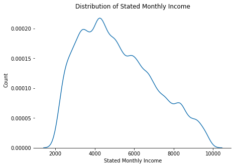

```python
plt.rcParams['figure.figsize'] = 7, 5
# plot
sns.distplot(df["StatedMonthlyIncome"], color='tab:blue', hist = False)
sns.despine(left = True)
# set title and label axes
label("Stated Monthly Income", "Count", "Distribution of Stated Monthly Income")
# Display the plot
plt.show()
```

### Bivariate Exploration

#### DebtToIncomeRatio vs. IsBorrowerHomeowner

```python
debt_home = df.groupby(["IsBorrowerHomeowner"], as_index = False)["DebtToIncomeRatio"].mean()
debt_home
```

|  | IsBorrowerHomeowner | DebtToIncomeRatio |
| --- | --- | --- |
| 0 | False | 0.225171 |
| 1 | True | 0.235488 |

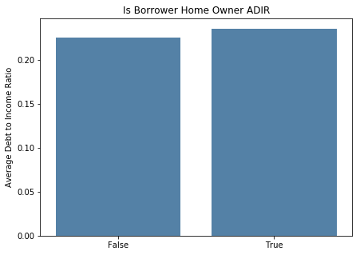

```python
sns.barplot(data = debt_home,
            x = "IsBorrowerHomeowner",
            y = "DebtToIncomeRatio",
            color = "steelblue",
);

label("", "Average Debt to Income Ratio", "Is Borrower Home Owner ADIR");
```

> - The average debt to ratio of home owner is higher than those that are not home owner

#### Borrower Rate and Borrower APR

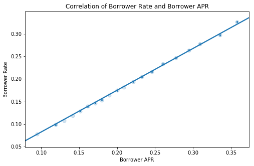

```python
plt.rcParams['figure.figsize'] = 8, 5

sns.regplot(data = df,
            x = 'BorrowerAPR',
            y='BorrowerRate',
           scatter_kws = {"alpha": 0.2},
           x_bins = 20)

# Label the axis
plt.xlabel("Borrower APR")
plt.ylabel("Borrower Rate")

# set title and label axes
label("Borrower APR", "Borrower Rate","Correlation of Borrower Rate and Borrower APR")

plt.show()
```

> - There is a very strong positive correlation between borrower rate and borrower apr

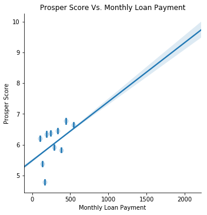

```python
plt.rcParams['figure.figsize'] = 8, 5
sns.lmplot(data = df,
            x = "MonthlyLoanPayment",
            y = "ProsperScore",
           scatter_kws = {"alpha": 0.2},
           x_bins = 10)
# set title and label axes
label("Monthly Loan Payment", "Prosper Score", "Prosper Score Vs. Monthly Loan Payment");
plt.show()
```

> - There is a positive correlation between Monthly Loan Payment and prosper score

#### Debt to Income Ratio and Occupation

```python
# Remove Nans, Other and Professional from Occupation column

frame = df.groupby(["Occupation"], as_index=False)["DebtToIncomeRatio"].mean()
```

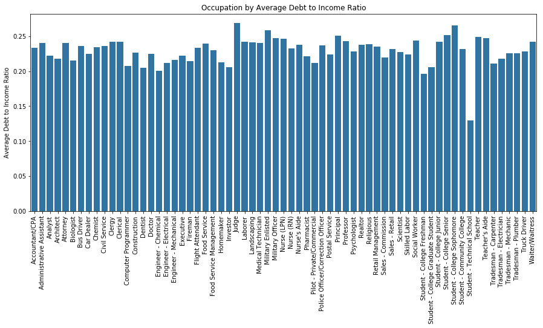

```python
plt.rcParams['figure.figsize'] = 15, 6

sns.barplot(data = frame,
           x = "Occupation",
           y = "DebtToIncomeRatio",
           ci = None,
           color = "tab:blue")
# set title and label axes
label("", "Average Debt to Income Ratio", "Occupation by Average Debt to Income Ratio")

plt.xticks(rotation = 90)
plt.show()
```

#### credit grade and BorrowerAPR

#### Question3:

Is there any relationship between interest rate and credit grade?

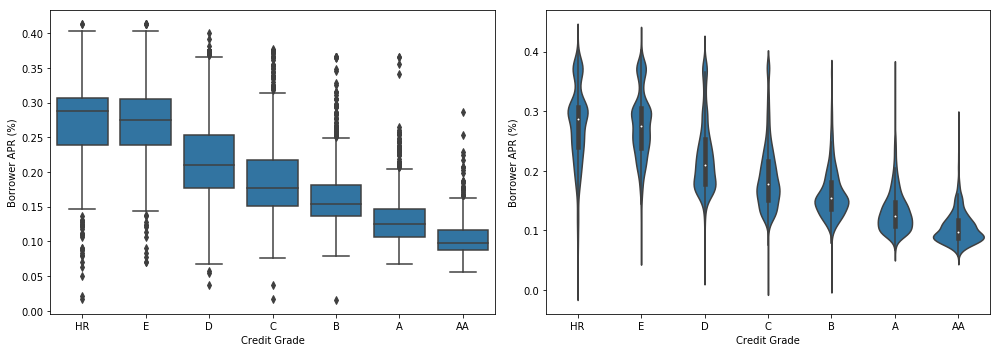

```python
plt.rcParams['figure.figsize'] = 14, 5
fig, ax = plt.subplots(ncols=2)

sns.boxplot(data = df,
           x = "CreditGrade",
           y = "BorrowerAPR",
           color = "tab:blue", ax = ax[0])

sns.violinplot(data = df,
           x = "CreditGrade",
           y = "BorrowerAPR",
           color = "tab:blue", ax=ax[1])

# label axes
ax[0].set_ylabel("Borrower APR (%)")
ax[0].set_xlabel("Credit Grade")
ax[1].set_ylabel("Borrower APR (%)")
ax[1].set_xlabel("Credit Grade")
plt.tight_layout()
plt.show()
```

#### Observation

> - The average borrower rate for a higher credit grade AA is lower than others.
> - The higher the risk, the higher the interest rate.

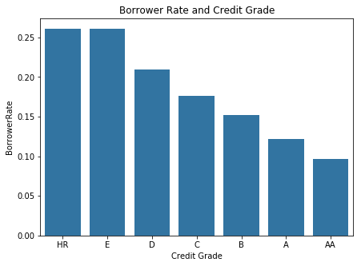

```python
plt.rcParams['figure.figsize'] = 7, 5

sns.barplot(data = df,
           x = "CreditGrade",
           y = "BorrowerRate",
           ci = None,
           color = "tab:blue")

# label the axes
plt.xlabel("")
plt.ylabel("BorrowerRate")

# set title and label axes
label("Credit Grade", "BorrowerRate", "Borrower Rate and Credit Grade")

# show the plot
plt.show()
```

> - Credit grade AA has the least borrower rate
> - People with credit grade HR and E will have to get loan at higher interest rate

#### Borrower Rate, Prosper Rating (Alpha) and ProsperScore

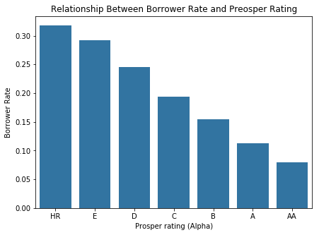

```python
plt.rcParams['figure.figsize'] = 7, 5

sns.barplot(data = df,
           x = "ProsperRating (Alpha)",
           y = "BorrowerRate",
           ci = None,
           color = "tab:blue")

# set title and label axes
label("Prosper rating (Alpha)", "Borrower Rate", "Relationship Between Borrower Rate and Preosper Rating")
# show the plot
plt.show()
```

> - The prosper rating (alpha) HR has the highest Borrower Rate. This means higher risk will be taken to give loan to those with this class of rating

#### Question 4:

> How does monthly loan payment affect the score of loan takers?

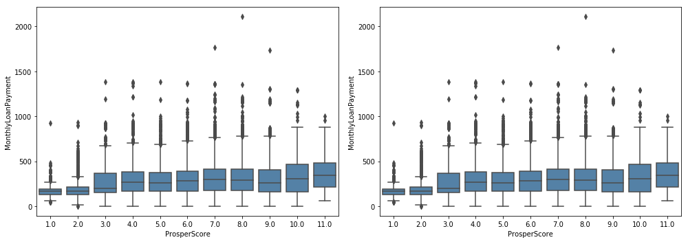

```python
plt.rcParams['figure.figsize'] = 14, 5
fig, ax = plt.subplots(ncols = 2)
sns.boxplot(data = df,
           x = "ProsperScore",
           y = "MonthlyLoanPayment",
           color = "Steelblue", ax=ax[0])

sns.boxplot(data = df,
           x = "ProsperScore",
           y = "MonthlyLoanPayment",
           color = "Steelblue", ax=ax[1])

# label axes
ax[0].set_ylabel("MonthlyLoanPayment")
ax[0].set_xlabel("ProsperScore")
ax[1].set_ylabel("MonthlyLoanPayment")
ax[1].set_xlabel("ProsperScore")
plt.tight_layout()
plt.show()
```

#### Observation

> it is observed that those who pay higher monthly loan receive a better score.

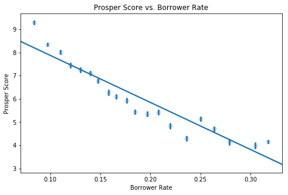

```python
plt.rcParams['figure.figsize'] = 8, 5
sns.regplot(data = df,
            x = "BorrowerRate",
            y = "ProsperScore",
           scatter_kws = {"alpha": 0.2},
           x_bins = 20)
# set the title
label("Borrower Rate", "Prosper Score", "Prosper Score vs. Borrower Rate")
plt.show()
```

### Multivariate Exploration

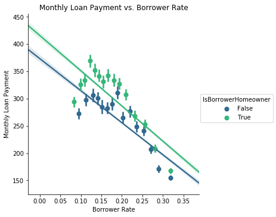

```python
plt.rcParams['figure.figsize'] = 7, 5
sns.lmplot(data = df, x=  "BorrowerRate", y = "MonthlyLoanPayment",
           hue = "IsBorrowerHomeowner", x_bins = 15,
          palette = "viridis")

# set title and label axes
label("Borrower Rate", "Monthly Loan Payment", "Monthly Loan Payment vs. Borrower Rate");
plt.show()
```

#### CreditGrade, BorrowerRate and IsBorrowerHomeOwner

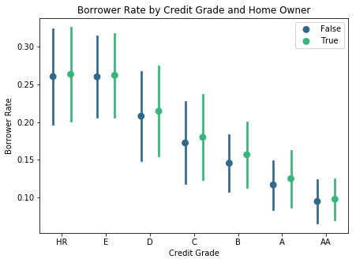

```python
plt.rcParams['figure.figsize'] = 7, 5
sns.pointplot(data = df,
           x = "CreditGrade",
           y = "BorrowerRate",
           hue = "IsBorrowerHomeowner",
            palette = "viridis",
              linestyles = "",
              dodge = 0.4, ci='sd'

)
# set legend location
plt.legend(loc = "upper right")
# label axes and set title
label("Credit Grade", "Borrower Rate", "Borrower Rate by Credit Grade and Home Owner");
```

> - We can see that low interest rate for higher credit grade and higher interest rate for lower credit grade'
> - On the average, the interest rate for the borrower taht are home owners is slightly higher than those that are not home owners.

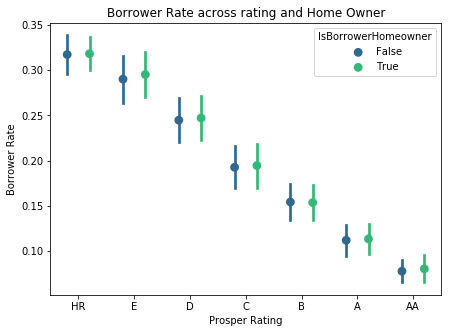

```python
# Set the figure size
plt.rcParams['figure.figsize'] = 7, 5
# plot
ax = sns.pointplot(data = df, x = 'ProsperRating (Alpha)',
                   y = 'BorrowerRate', hue = 'IsBorrowerHomeowner',
                   palette = 'viridis', linestyles = '',
                   dodge = 0.4, ci='sd')
# Set title and label axes
label('Prosper Rating', 'Borrower Rate','Borrower Rate across rating and Home Owner')
# Show the plot
plt.show()
```

#### Heat Map

```python
numeric_var = ["BorrowerAPR", "BorrowerRate", "StatedMonthlyIncome", "MonthlyLoanPayment",
              "ProsperScore", "DebtToIncomeRatio"]
```

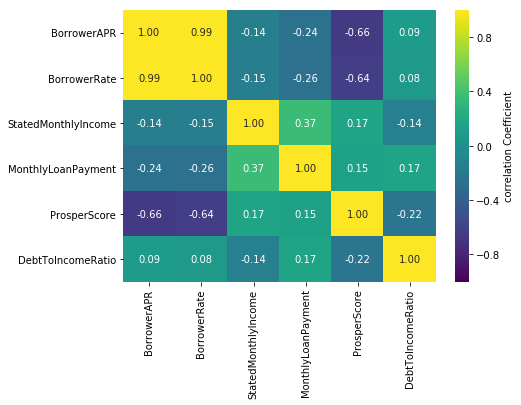

```python
corr = df[numeric_var].corr(method = "pearson")

plt.rcParams['figure.figsize'] = 7, 5
sns.heatmap(corr, fmt = ".2f",
           cbar_kws={'label': 'correlation Coefficient'},
           cmap='viridis', annot=True, vmin=-1, vmax=1)
plt.show()
```

> - Aside Borrower Rate and Borrower APR, there is weak correlation among Stated Monthly Income, Monthly Loan Payment, Prosper Score and Debt To Income Ratio.

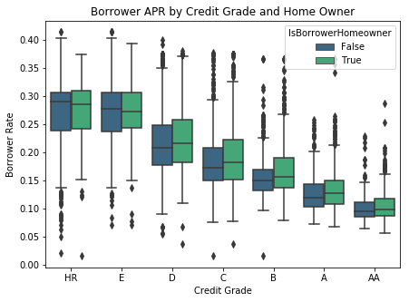

```python
plt.rcParams['figure.figsize'] = 7, 5

sns.boxplot(data = df,
           x = "CreditGrade",
           y = "BorrowerAPR",
           hue = "IsBorrowerHomeowner",
            palette = "viridis"
)
# Set label and title
label("Credit Grade", "Borrower Rate", "Borrower APR by Credit Grade and Home Owner");
```

> - We can see that there is low interest rate for higher credit grade and higher interest rate for lower credit grade'
> - On the average, the interest rate for the borrower that are home owners is higher than those that are not except for credit grade HR and E.

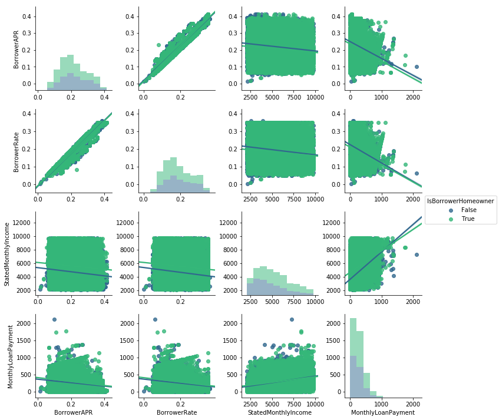

```python
num_vars = ["BorrowerAPR", "BorrowerRate", "StatedMonthlyIncome", "MonthlyLoanPayment"]
sns.pairplot(data = df,
             vars = num_vars,
            kind = "reg",
            hue = "IsBorrowerHomeowner",
            palette = "viridis",
             diag_kws = {"alpha":0.5}
            );
```

#### Question 5:

> 1. How does credit rate, monthly loan payment affect borrower APR?

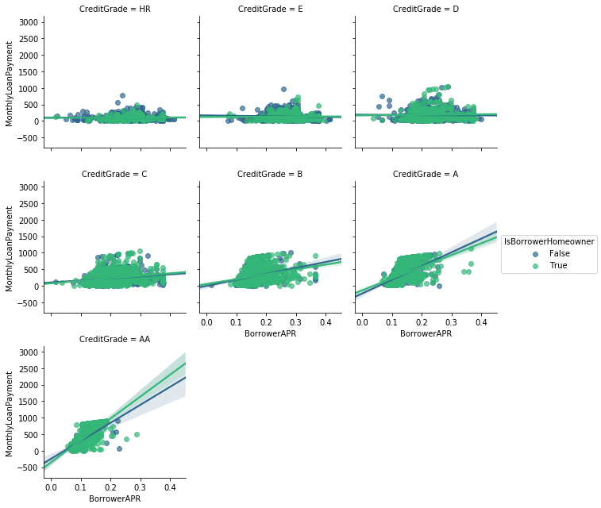

```python
sns.lmplot(data = df,
           x = "BorrowerAPR",
            y = "MonthlyLoanPayment",
           col = "CreditGrade",
          palette = "viridis",
           hue = "IsBorrowerHomeowner",
           col_wrap = 3,
           size = 3,
           col_order = grade_order,
          scatter_kws = {"alpha":0.7});
```

#### Observation

> - The correlation between the monthly loan payment and Borrower APR keeps becoming more positively correlated as the credit grade keeps getting better.

### Conclusions

> In the exploration, I found out that the interest rate is negatively correlated with monthly loan payment and prosper score. The borrower APR also decreases with the increasingly better rating. Borrowers with the best Prosper ratings have the lowest APR. It means that the Prosper rating has a strong effect on borrower APR. But people with lower ratings tend to borrow less money, decreasing APR could encourage them to borrow more. Further more, I discovered that there is low interest rate for higher credit grade and higher interest rate for lower credit grade and on the average, the interest rate for the borrower that are home owners is higher than those that are not

### Limitations

The Exploratory Data Analysis is a good way to investigate the data using clear and interesting visualizations. However, to make final statement about the relationships among variables we need to conduct statistical test and probably build some predictive models.